# Técnicas básicas para previsão

26 de agosto de 2019

## O que vamos aprender hoje?

1. Dessazonalização, interpolação e algumas visualizações úteis.

**2. rafa: algoritmo para previsão de séries temporais.**

**Objetivos gerais**

**Nossos insumos**

- Série temporal: **Taxa de desocupação (PED/DF)**
- R: pacote *forecast* (Hyndman et al, 2019).
- R: pacote *rafa* (Leripio, 2019)

## Configurações preliminares

- Instalar os pacotes necessários

[figure not shown]

- Carregar os pacotes instalados

```r
library(forecast)
library(seasonal)
library(tidyverse)
```

## Importando nossos dados

- **Repositório**: https://github.com/leripio/mini-curso-codeplan
- Fazer o download do arquivo: *ped.xlsx*.
- Abra o R e importe o arquivo através do botão *Import Dataset*.

[figure not shown]

## Adequando os dados

- O pacote *forecast* (versão <= 8.5) utiliza objetos de classe ‘ts’.

```r
ped_ts <- ts(ped$TD, start = c(2012,3), frequency = 12)

ped_ts
```

```
##       Jan  Feb  Mar  Apr  May  Jun  Jul  Aug  Sep  Oct  Nov  Dec
## 2012           12.8 12.7 12.6 12.4 12.2 12.1 11.5 11.0 10.5 10.6
## 2013 11.4 12.2 12.6 12.3 11.6 11.5 11.4 11.6 11.4   NA   NA   NA
## 2014   NA   NA   NA   NA   NA   NA   NA   NA   NA   NA 11.3 11.0
## 2015 11.3 11.5 12.5 13.3 13.7 13.5 12.9 13.5 13.8 14.3 14.2 14.5
## 2016 15.6 16.3 17.1 17.5 17.8 18.0 17.8 17.4 17.2 17.5 18.5 18.6
## 2017 19.3 20.0 20.7 20.5 20.4 19.9 19.5 18.7 18.7 18.8 18.4 17.9
## 2018 17.7 18.2 18.9 19.2 19.5 19.2 18.7 18.1 17.9 18.4 18.5 18.3
## 2019 18.3 18.7 19.5 19.9 19.4 19.5
```

Problema: observações ausentes (NA)!

## Antes de prosseguir…

- Convém visualizar graficamente os dados:

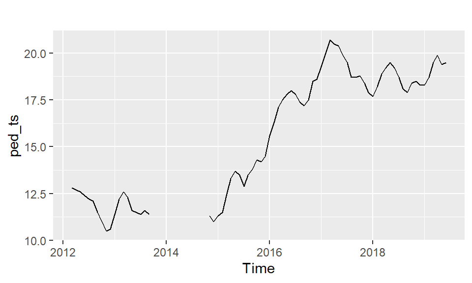

```r
library(forecast)

autoplot(ped_ts)
```

## Preenchendo os valores ausentes

- Alguns métodos de previsão aceitam valores ausentes (NA’s), outros não.
- Basicamente, precisamos adicionar os valores ausentes para ligar os pontos:

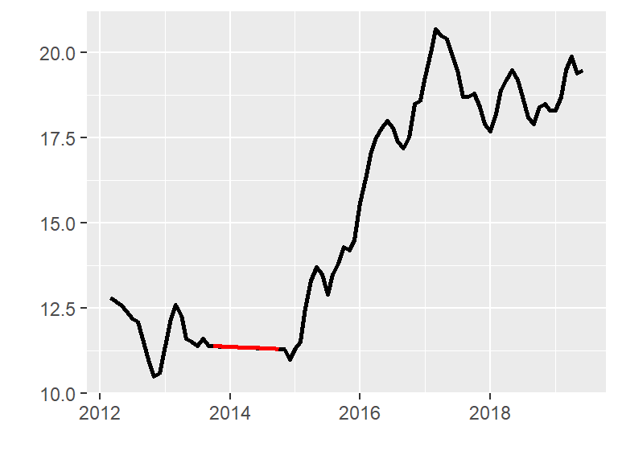

- **Porém, é necessário levar a conta o padrão sazonal da série.**

## Começando com o pacote *forecast*

- Função **na.interp()** considera a sazonalidade.

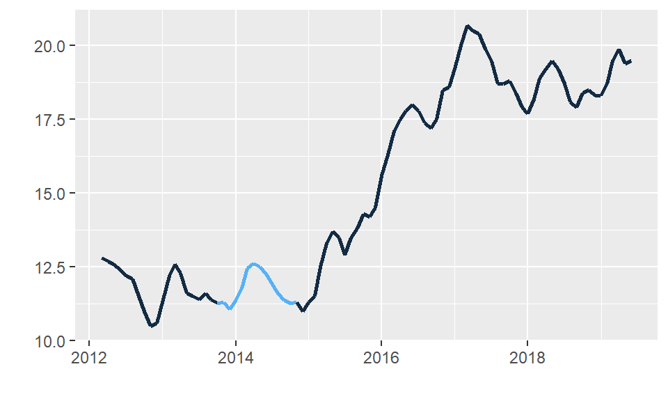

```r
library(forecast)

ped_completa <- na.interp(ped_ts)

autoplot(ped_completa)
```

## Por falar em sazonalidade…

- Funções úteis para visualizar sazonalidade: **ggseasonplot()** e **ggmonthplot()**

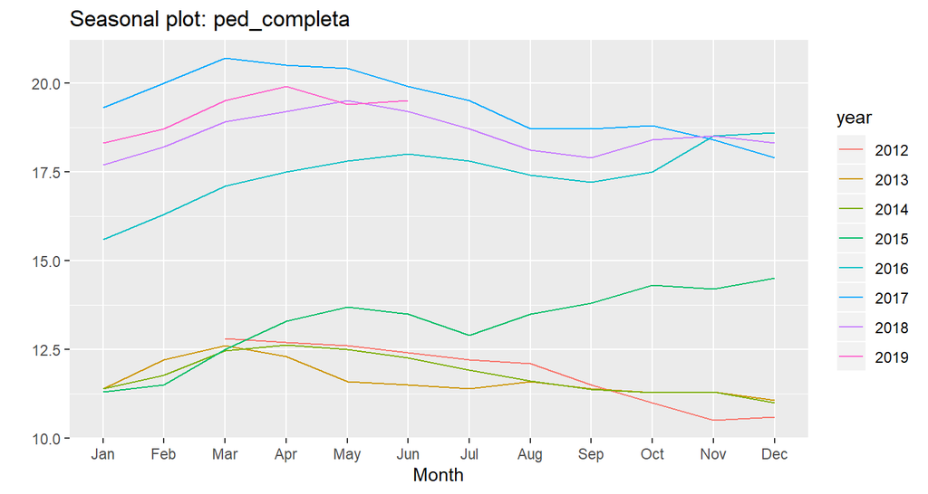

```r
ggseasonplot(ped_completa)
```

## Por falar em sazonalidade…

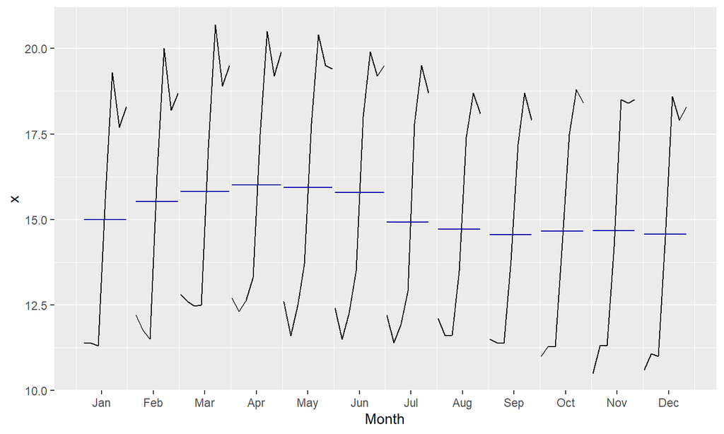

```r
ggmonthplot(ped_completa)
```

## Você deve estar se perguntando…

- Ok, mas agora eu quero retirar a sazonalidade!

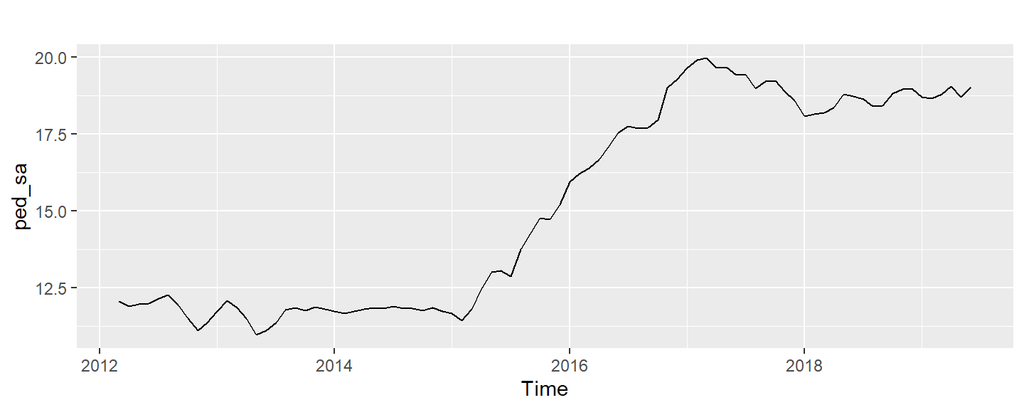

```r
library(seasonal)

ped_sa <- ped_completa %>% seas() %>% final()

autoplot(ped_sa)
```

## Será que removeu a sazonalidade?

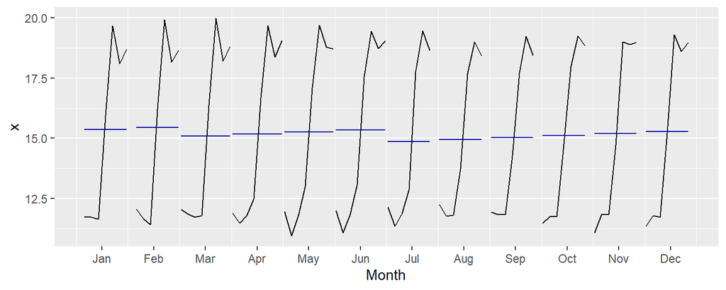

```r
ggmonthplot(ped_sa)
```

- Ajustes sazonais nunca são perfeitos.
- Séries longas ajudam o processo.
- Mas o resultado é bom!

## Previsão: visão geral

- Pacote *forecast* conta com diversos métodos implementados
  - **auto.arima()**
  - **ets()**
  - **tbats()**
  - **meanf()**
  - …

## Exemplo: auto.arima()

```r
ped_prev_arima <- ped_completa %>% auto.arima() %>% forecast(h = 6)

ped_prev_arima
```

```
##          Point Forecast    Lo 80    Hi 80    Lo 95    Hi 95
## Jul 2019       19.25150 18.79979 19.70321 18.56066 19.94233
## Aug 2019       18.97708 18.20662 19.74754 17.79876 20.15539
## Sep 2019       18.85898 17.82473 19.89323 17.27723 20.44073
## Oct 2019       19.06069 17.80330 20.31809 17.13767 20.98372
## Nov 2019       19.11382 17.66253 20.56510 16.89427 21.33337
## Dec 2019       18.97414 17.35033 20.59794 16.49075 21.45753
```

## Exemplo: auto.arima()

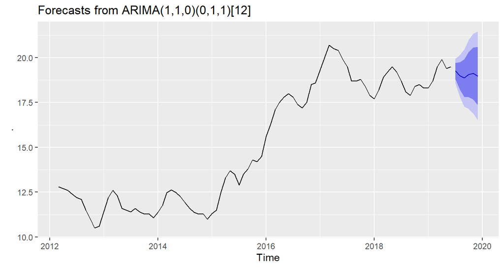

```r
autoplot(ped_prev_arima)
```

## Mas poderia usar outros métodos…

```r
ped_completa %>% ets() %>% forecast(h = 4)
```

```
##          Point Forecast    Lo 80    Hi 80    Lo 95    Hi 95
## Jul 2019       19.12389 18.68402 19.56375 18.45117 19.79660
## Aug 2019       18.89887 18.23759 19.56014 17.88753 19.91020
## Sep 2019       18.72486 17.86856 19.58117 17.41526 20.03447
## Oct 2019       18.76296 17.72257 19.80335 17.17182 20.35409
```

```r
ped_completa %>% tbats() %>% forecast(h = 4)
```

```
##          Point Forecast    Lo 80    Hi 80    Lo 95    Hi 95
## Jul 2019       19.15650 18.77640 19.53661 18.57519 19.73782
## Aug 2019       18.91698 18.26943 19.56452 17.92664 19.90731
## Sep 2019       18.67116 17.82423 19.51809 17.37589 19.96643
## Oct 2019       18.70280 17.70106 19.70454 17.17077 20.23483
```

## Como saber qual o melhor?

- A amostra da PED contém 88 observações:
  1. Vamos separar as primeiras 64 observações para estimar o modelo;
  2. Em seguida, gerar previsão para 24 períodos à frente;
  3. Por fim, vamos **comparar** as 24 previsões com as 24 realizações de fato;

## Como comparar?

- Através de estatísticas de acurácia.
- Basicamente, calculam alguma medida que **sumariza** o desvio dos valores previstos em relação aos valores observados.
- Ex: RMSE e MAE

- Mas você não vai precisar calcular à mão!
- O pacote *forecast* dispõe da função **accuracy()** para isso.

## Vamos comparar os modelos?

Passo 1: definir as amostras de treino e teste

```r
ped_treino <- window(ped_completa, end = c(2017,6))

ped_teste <- window(ped_completa, start = c(2017,7))
```

Passo 2: fazer as previsões p/ 24 períodos

```r
ped_arima <- ped_treino %>% auto.arima() %>% forecast(h = 24)

ped_ets <- ped_treino %>% ets() %>% forecast(h = 24)
```

## Vamos comparar os modelos

Passo 3: calcular medidas de acurácia

```r
accuracy(ped_arima, ped_teste)
```

```
##                    MAE      RMSE
## Training set 0.2255086 0.3030171
## Test set     2.3801099 2.6112131
```

```r
accuracy(ped_ets, ped_teste)
```

```
##                    MAE      RMSE
## Training set 0.3027817 0.3903309
## Test set     0.6003405 0.7602244
```

Diferença elevada entre a acurácia dentro e fora da amostra no modelo arima reflete pouca capacidade de generalização!

## De fato…

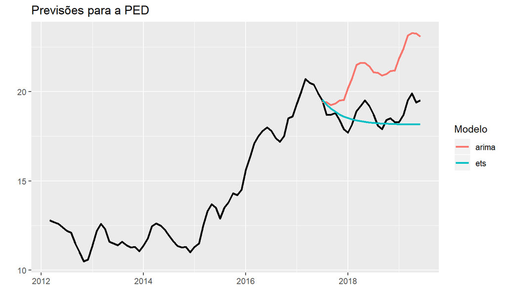

## E o algoritmo, onde entra nisso?

- Generalizar o processo de busca pelo melhor modelo.
- Além disso, introduz algumas ferramentas de refinamento:
  1. Previsão central e intervalos mais robustos (*bagging*)
  2. Opção de cálculo de acurácia mais robusto (CV).
  3. Opção de medir acurácia direcional.

## Me convenceu, quero usar!

Passo 1: instalar o pacote **rafa**

```r
library(devtools)

install_github("leripio/rafa")
```

Passo 2: utilizar a função *auto_forecast()*

```r
library(rafa)

ped_rafa <- auto_forecast(ped_completa, test = c(2017,6), h = 6)
```

O objeto criado *ped_rafa* contém alguns elementos:

1. **fc**: as previsões centrais e intervalos.
2. **ac**: acurácia dos modelos.

## Acurácia dos modelos

```r
ped_rafa$acc
```

```
## # A tibble: 13 x 5
##    Model        MAE  RMSE Right Wrong
##    <chr>      <dbl> <dbl> <int> <int>
##  1 tbats      0.527 0.634    15     9
##  2 ets        0.600 0.760    20     4
##  3 ses        1.15  1.30     13    11
##  4 arfima     1.36  1.72     16     8
##  5 thetaf     2.01  2.11     11    13
##  6 auto.arima 2.38  2.61     11    13
##  7 nnetar     2.78  3.02     15     9
##  8 hw         3.10  3.32     11    13
##  9 elm        3.20  3.41     11    13
## 10 holt       4.26  5.30     13    11
## 11 splinef    4.59  5.69     13    11
## 12 meanf      4.86  4.90     11    13
## 13 StructTS   5.15  6.31     13    11
```

## Previsões do melhor modelo

```r
ped_rafa$fc
```

```
## # A tibble: 6 x 4
##       h Point Lower_0.95 Higher_0.95
##   <dbl> <dbl>      <dbl>       <dbl>
## 1     1  18.8       17.8        19.5
## 2     2  18.6       17.6        19.3
## 3     3  18.3       17.2        19.2
## 4     4  18.3       17.2        19.3
## 5     5  18.2       17.0        19.1
## 6     6  18.0       16.7        19.0
```

## Obrigado!

- Repositório: http://github.com/leripio
- Blog pessoal: http://www.rleripio.com.br/blog
- Contato: leripiorenato@gmail.com